# Starting with smooth descent

# Visualization

Looking at plain numbers can sometimes be overwhelming. We’ve included some visualization tools to help understand the output of this package. There are three main functions: `graphical_genotype()`, `iterplot()` and `recdist_plot()`.

## IBD visualization

The `graphical_genotype()` function is useful to visualize probability matrices, such as the IBD matrices or the error matrices. It can plot either a single matrix or a list of matrices, providing very similar outputs. By default, low values will be given a yellow colour, while high values will be given a red colour. We can identify which homologue has been inherited by each individual by looking at stretches of red.

```r
#Here we see the IBD matrices for all homologues and all individuals
graphical_genotype(sd1$predIBD)
```

[output not shown]

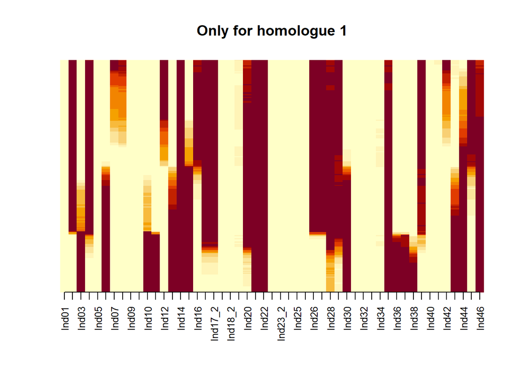

```r
#Or for all individuals but a single homologue
graphical_genotype(sd1$predIBD$H1_P1, main = "Only for homologue 1")
```

It is also useful to visualize single individuals if combined with the `extract()` utility function.

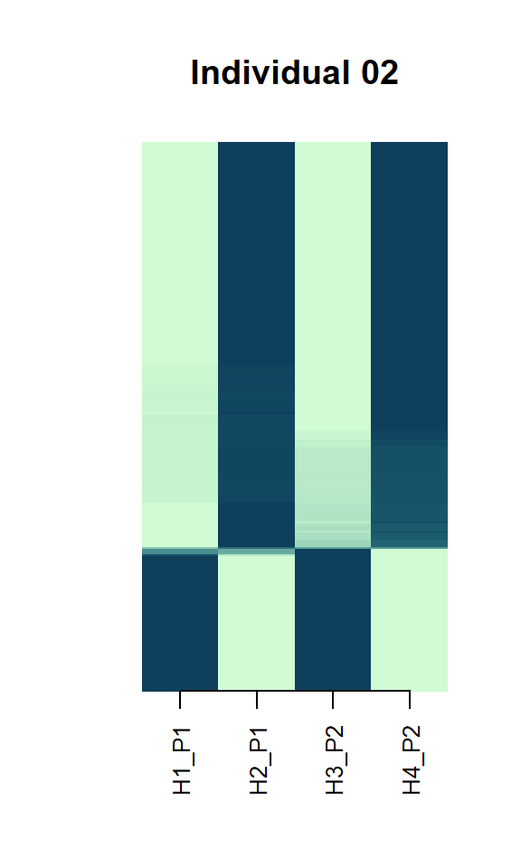

```r
ibd <- extract(sd1$pred,c("Ind02"))
#Title and colours can also be easily changed.
graphical_genotype(ibd, main = "Individual 02",
                   col = hcl.colors(300,"Dark Mint"))
```

If we want to extract IBDs from multiple individuals we can also use `extract()`

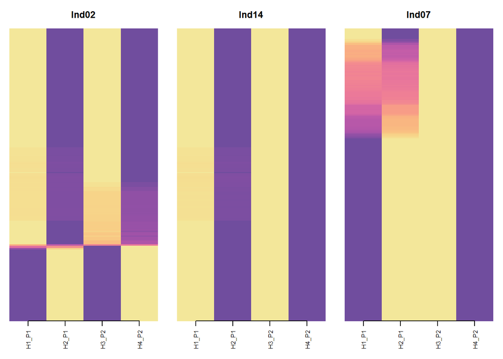

```r
ibd <- extract(sd1$pred,c("Ind02","Ind14","Ind07"))
graphical_genotype(ibd, col = hcl.colors(300,"Sunset"))
```

## Map iteration visualization

One of the features of `SmoothDescent` is to iteratively improve genetic maps. It is often useful to compare the maps from all iterations to see which changes have been made as the algorithm progressed. We can use `iterplot()` for that. This function expects a list of maps.

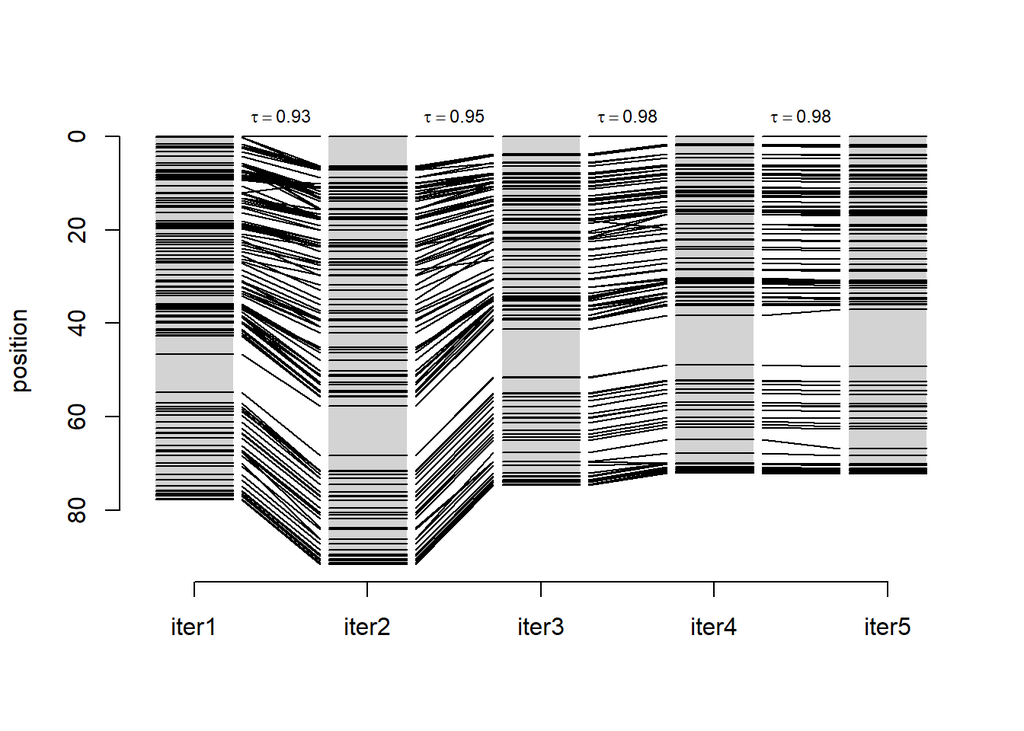

```r
#We can create a list of maps from the output of smooth_map_iter()
maplist <- extract(sm5,"newmap",simplify = F)
#With this we don't see the first map (iteration 0)
iterplot(maplist)
```

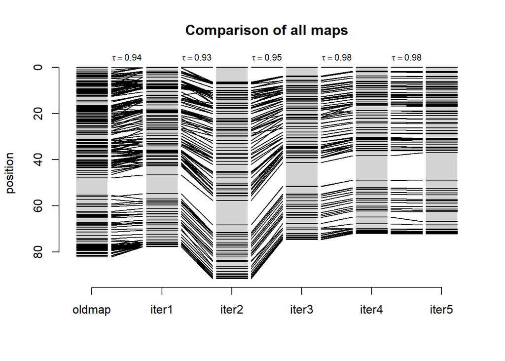

```r
maplist <- c(sm5$iter1["oldmap"],maplist)
iterplot(maplist,main = "Comparison of all maps")
```

The tau indicates the order correlation between adjacent maps.

## Recdist visualization

The `recdist_plot()` function helps us visualize the recombination-distance relationship of each new map calculated. This can be useful to manually inspect which iteration has produced the best output. This function only accepts a single recdist matrix at a time.

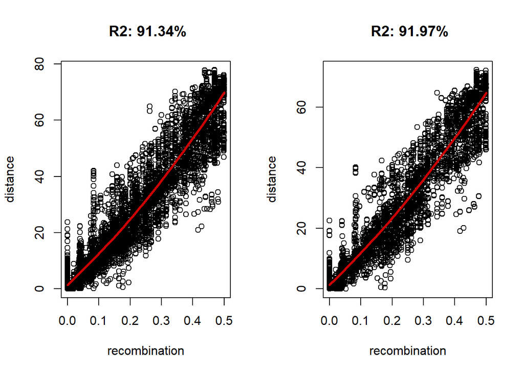

```r
par(mfrow = c(1,2))
recdist_plot(sm5$iter1$recdist)
recdist_plot(sm5$iter5$recdist)
```

In these examples the recombination-distance relationship is very good. However, sometimes we can find very funky relationships that indicate something is wrong in the mapping.

# Parameters

This section will help you understand the different parameters that influence the behaviour of smooth descent. The default parameters should work well in most cases, but if you want to tweak things or experiment with the algorithm, this section will help you better understand the impact of each parameter.

### Prediction interval

IBD prediction is performed as a moving average within a window around each marker. By default 10cM are used around each marker. You might want to increase this if your data is very sparse. If you use a physical map instead, expressed in bp, you should definitely increase this value for example to 10000bp.

Let’s look at an example where we compare a predicted interval of 10 cM (default), 30 cM (large) or 2 cM (small)

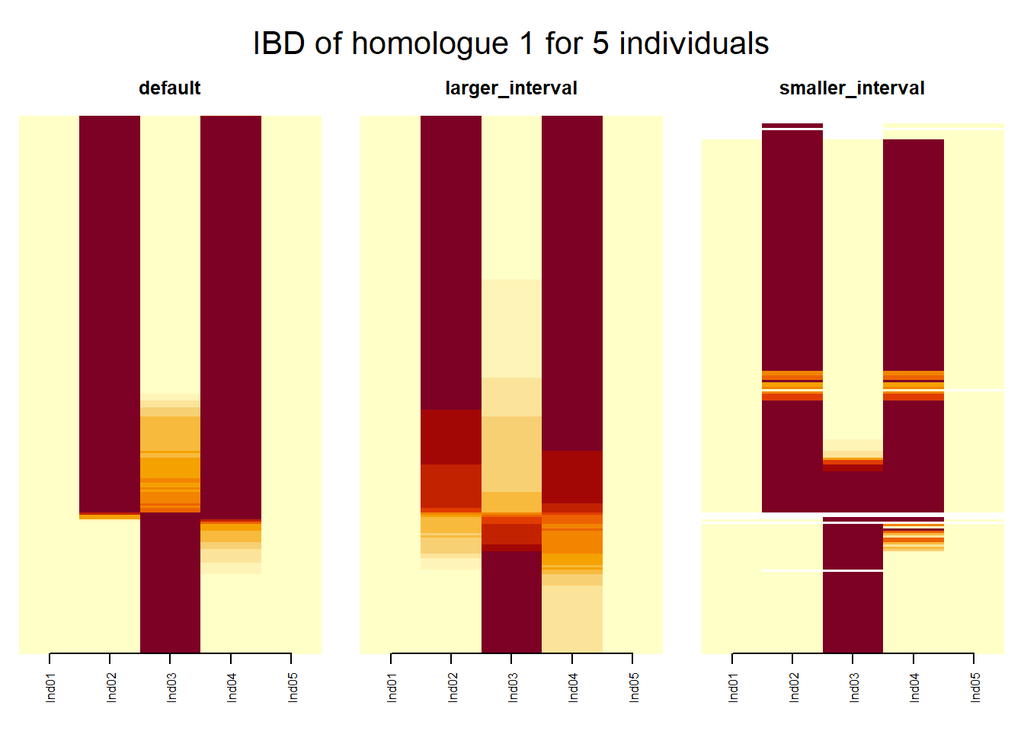

```r
#Here we will test the effect of a different prediction intervals
sd_default <- smooth_descent(geno = geno, homologue = hom, map = map,
                             ploidy = 2, p1name = "P1", p2name = "P2",
                             verbose = F)
sd_int_large <- smooth_descent(geno = geno, homologue = hom, map = map,
                             ploidy = 2, p1name = "P1", p2name = "P2",
                             prediction_interval = 30,verbose = F)
sd_int_small <- smooth_descent(geno = geno, homologue = hom, map = map,
                             ploidy = 2, p1name = "P1", p2name = "P2",
                             prediction_interval = 2,verbose = F)
H1 <- list(default = sd_default$predIBD$H1_P1[,1:5],
           larger_interval = sd_int_large$predIBD$H1_P1[,1:5],
           smaller_interval = sd_int_small$predIBD$H1_P1[,1:5])

graphical_genotype(H1, main = "IBD of homologue 1 for 5 individuals")
```

We can see how larger intervals produce longer regions of uncertain IBD probabilities for the different individuals. On the other hand, smaller intervals have the problem that in some cases very few markers provide information for the prediction, and consequently there are missing values and IBD inaccuracies.

### Prediction threshold

This parameter is used in the IBD imputation step. If the predicted IBDs are below this threshold (0.8 by default) they will not be used to impute new genotypes. In practice, lowering this threshold results in wrong imputations. Increasing it can be useful if you want to be very stringent.

Let’s compare results using the default threshold, a stringent threshold (1) or a lax threshold (0)

```r
#Here we will test the effect of different prediction thresholds.
sd_default <- smooth_descent(geno = geno, homologue = hom, map = map,
                             ploidy = 2, p1name = "P1", p2name = "P2",
                             verbose = F)
#We will only accept imputations if IBD probabilities are 1
sd_th_large <- smooth_descent(geno = geno, homologue = hom, map = map,
                             ploidy = 2, p1name = "P1", p2name = "P2",
                             prediction_threshold = 1,verbose = F)
#We accept any imputation
sd_th_small<- smooth_descent(geno = geno, homologue = hom, map = map,
                             ploidy = 2, p1name = "P1", p2name = "P2",
                             prediction_threshold = 0,verbose = F)

#The proportion of changes
def_change <- mean(sd_default$newgeno != sd_default$oldgeno)
large_change <- mean(sd_th_large$newgeno != sd_default$oldgeno)
small_change <- mean(sd_th_small$newgeno != sd_default$oldgeno)

print(paste0("By default we impute ",round(def_change*100,2),"% of genotypes"))
```

```
## [1] "By default we impute 1.14% of genotypes"
```

```r
print(paste0("With increased stringency we impute ",
             round(large_change*100,2),"% of genotypes"))
```

```
## [1] "With increased stringency we impute 1.06% of genotypes"
```

```r
print(paste0("With decreased stringency we impute ",
             round(small_change*100,2),"% of genotypes"))
```

```
## [1] "With decreased stringency we impute 1.14% of genotypes"
```

In this example there are no erroneous markers with low IBD probabilities, so decreasing the prediction threshold has no effect.

### Prediction points

Normally, IBD prediction happens per marker, so there’s as many steps as number of markers. For datasets with large marker numbers (thousands of markers), this can be very slow and add very little information to the estimation.Instead of computing a predicted IBD independently for each marker, one can predict IBD at a limited number of points along the chromosome and then use that output to estimate the predicted IBD at each marker. We recommend using somewhere around 1000 steps, so it only makes sense to use this feature if you have >1000 markers along your chromosome.

To activte this behaviour you can specify a number of steps by using the `prediction_points` argument. To illustrate this behaviour we’ll force the prediction to happen at 1000 points or 10 points only.

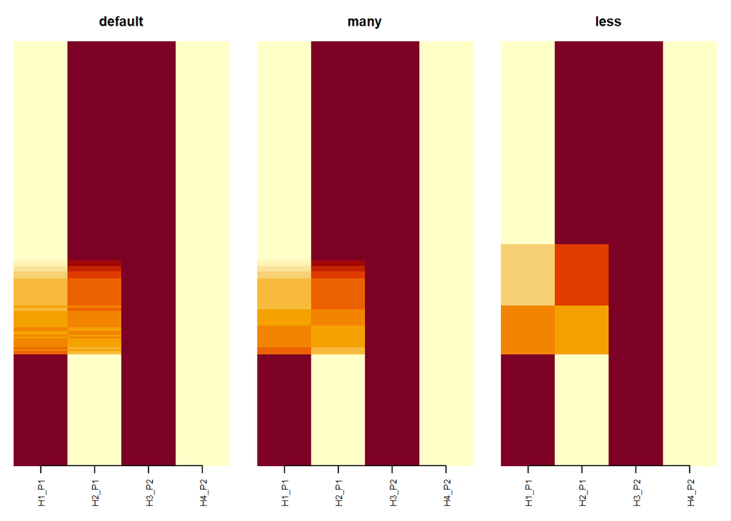

```r
sd_default <- smooth_descent(geno = geno, homologue = hom, map = map,
                             ploidy = 2, p1name = "P1", p2name = "P2",
                             verbose = F)
sd_many_points <- smooth_descent(geno = geno, homologue = hom, map = map,
                             ploidy = 2, p1name = "P1", p2name = "P2",
                             verbose = F, prediction_points = 1000)
sd_less_points <- smooth_descent(geno = geno, homologue = hom, map = map,
                             ploidy = 2, p1name = "P1", p2name = "P2",
                             verbose = F, prediction_points = 10)

comparison <- lapply(list(default = sd_default$predIBD,
                          many = sd_many_points$predIBD,
                          less = sd_less_points$predIBD),extract,"Ind03")

graphical_genotype(comparison)
```

With many points the results are almost identical with the default, even in this case where there’s relatively low marker density. In a higher density example the differences would be even smaller. With few points the results are clearly worse, since we’ve only calculated IBD at 10 points and extrapolated that to all markers.

### Error threshold

During the error assignment step, all markers that have an error probability above this threshold will be considered errors. The default of 0.8 works quite well, but if you want to be very stringent you could lower it. Values below 0.5 might yield strange output, since markers with larger probability of not being an error would be assigned to the error category too.

```r
#Here we will test the effect of error thresholds
sd_default <- smooth_descent(geno = geno, homologue = hom, map = map,
                             ploidy = 2, p1name = "P1", p2name = "P2",
                             verbose = F)
#Only if the error probability is above 0.95 we consider it an error (very lax)
sd_th_large <- smooth_descent(geno = geno, homologue = hom, map = map,
                             ploidy = 2, p1name = "P1", p2name = "P2",
                             error_threshold = 0.95,verbose = F)
#Any marker with an error probability above 0.5 is considered an error (very stringent)
sd_th_small<- smooth_descent(geno = geno, homologue = hom, map = map,
                             ploidy = 2, p1name = "P1", p2name = "P2",
                             error_threshold = 0.5,verbose = F)

#The proportion of errors
#All error matrices have the same markers identified as errors
def_change <- mean(sd_default$error$H1_P1)
large_change <- mean(sd_th_large$error$H1_P1)
small_change <- mean(sd_th_small$error$H1_P1)

print(paste0("By default we consider ",round(def_change*100,2),"% of genotypes as errors"))
```

```
## [1] "By default we consider 1.19% of genotypes as errors"
```

```r
print(paste0("With decreased stringency we cosider ",
             round(large_change*100,2),"% of genotypes as errors"))
```

```
## [1] "With decreased stringency we cosider 0.75% of genotypes as errors"
```

```r
print(paste0("With increased stringency we consider ",
             round(small_change*100,2),"% of genotypes as errors"))
```

```
## [1] "With increased stringency we consider 2.5% of genotypes as errors"
```

### Non-informative markers

This parameter (`non_inf`) defines the interval of IBD probabilities that are ignored during the IBD prediction step. In diploids this has no effect, since probabilities can only be 0, 1 or 0.5. Thus, any interval containing 0.5 will work equally well. In polyploids, different intervals will produce different predictions. The default of 0.3 to 0.7 works pretty well in tetraploids. Reducing the interval (to 0.4 to 0.6 for instance) gives less certain IBD predictions. Non-symmetric intervals can be used too… if you think that’s sensible.

### Max distance

This parameter determines the maximum distance at which any marker is allowed to be from other markers. For example, if `max_distance` is 3, any marker whose closest marker is at a distance larger than 3 is eliminated. In practice, a `max_distance` of 5 works well in relatively dense maps. Larger values might be needed for sparser maps. Use a very large value to prevent this behaviour.

### Interactions

All parameters that affect the prediction process (`prediction_interval`, `prediction_threshold`, `error_threshold` and `non_inf`) will impact each other and the final outcome. More uncertain IBD probabilities (larger `prediction_interval`) will lead to less confident genotype imputations. A lower `error_threshold` will detect more markers as errors, which will try to be imputed, but will likely have less certain IBDs and require a lower `prediction_threshold` to affect the estimated genotypes. Consider parameter interactions carefully when fine-tuning them.

# Basic functions

You may be interested in the more basic functions if you’re looking to experiment with the algorithm yourself:

- `calc_IBD()`: to calculate observed IBDs based on simple assortment of alleles.
- `predict_IBD()`: to predict expected IBDs based on observed IBDs.
- `genotype()`: to obtain new genotypes based on an IBD matrix.

### Calculate IBD

To calculate IBD we use genotype and parental homologue information. The `calc_IBD()` function can take a single marker or a matrix of markers (not a vector). The output will depend on the input. This function obtains probabilities based on a random allele assortment assumption.

```r
#For a single marker
calc_IBD(geno = 1,p1hom = c(h1 = 0, h2 = 1), p2hom = c(h3 = 0,h4 = 0), ploidy = 2)
```

```
##      h1 h2  h3  h4
## [1,]  0  1 0.5 0.5
```

```r
#Tetraploid probabilities
calc_IBD(geno =2,p1hom = c(0,0,1,0),p2hom = c(0,1,0,1), ploidy = 4)
```

```
##           [,1]      [,2]      [,3]      [,4]      [,5]      [,6]      [,7]
## [1,] 0.4761905 0.4761905 0.5714286 0.4761905 0.2857143 0.7142857 0.2857143
##           [,8]
## [1,] 0.7142857
```

```r
#Impossible genotype
calc_IBD(geno = 2,p1hom = c(0,1),p2hom = c(0,0), ploidy = 2)
```

```
##      [,1] [,2] [,3] [,4]
## [1,]   NA   NA   NA   NA
```

```r
#For a single individual the genotype input must be a one column matrix
calc_IBD(geno[1:10,3,drop = F],
         p1hom = hom[1:10,1:2],
         p2hom = hom[1:10,3:4],ploidy = 2)
```

```
## $H1_P1
##     Ind01
## m1    0.5
## m2    0.5
## m3    0.5
## m4    0.5
## m5    0.5
## m6    0.5
## m7    0.5
## m8    0.5
## m9    0.5
## m10   0.5
##
## $H2_P1
##     Ind01
## m1    0.5
## m2    0.5
## m3    0.5
## m4    0.5
## m5    0.5
## m6    0.5
## m7    0.5
## m8    0.5
## m9    0.5
## m10   0.5
##
## $H3_P2
##     Ind01
## m1    1.0
## m2    1.0
## m3    1.0
## m4    1.0
## m5    1.0
## m6    1.0
## m7    0.5
## m8    1.0
## m9    1.0
## m10   1.0
##
## $H4_P2
##     Ind01
## m1    0.0
## m2    0.0
## m3    0.0
## m4    0.0
## m5    0.0
## m6    0.0
## m7    0.5
## m8    0.0
## m9    0.0
## m10   0.0
```

### Predict IBD

This function uses an observed IBD matrix and a map to compute predicted IBDs using a windowed average method. The prediction also ignores “non-informative” markers, markers which have an uncertain probability (rather than low or high probability for a given homologue). The `predict_IBD()` function takes as input vectors, lists or matrices.

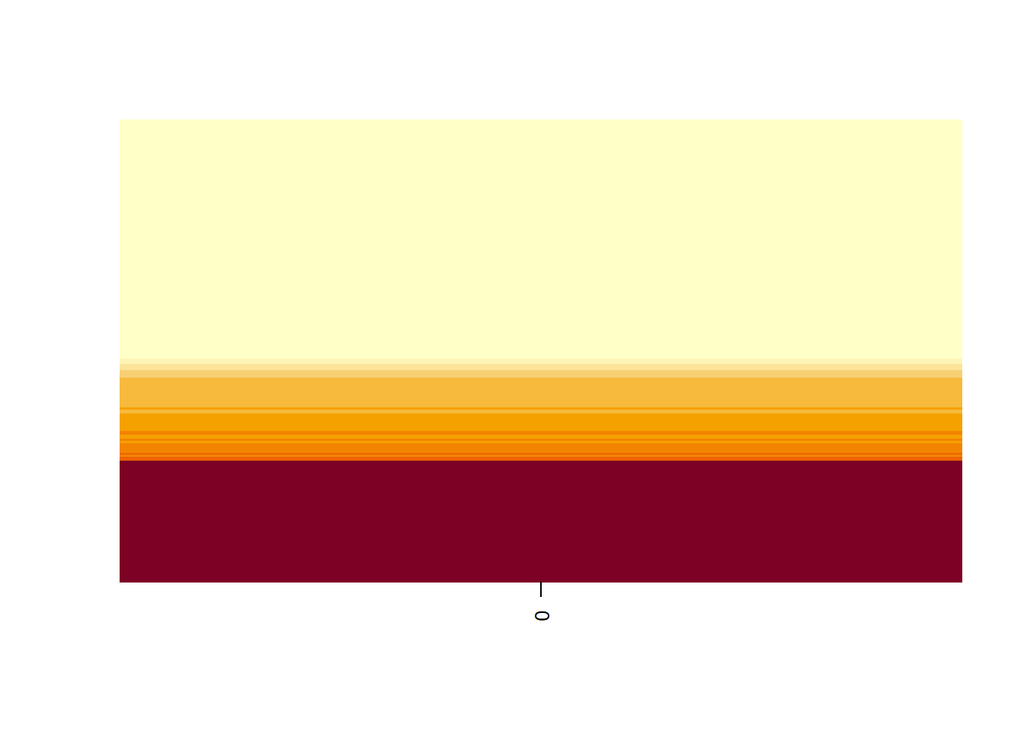

```r
#We calculate IBDs removing the genotypes of the parents
IBD <- calc_IBD(geno[,-1:-2],p1hom = hom[,1:2],p2hom = hom[,3:4])

#One parental homologue for one individual: a named vector
ibd <- predict_IBD(IBD$H1_P1[,3],map = map)
graphical_genotype(matrix(ibd,ncol = 1))
```

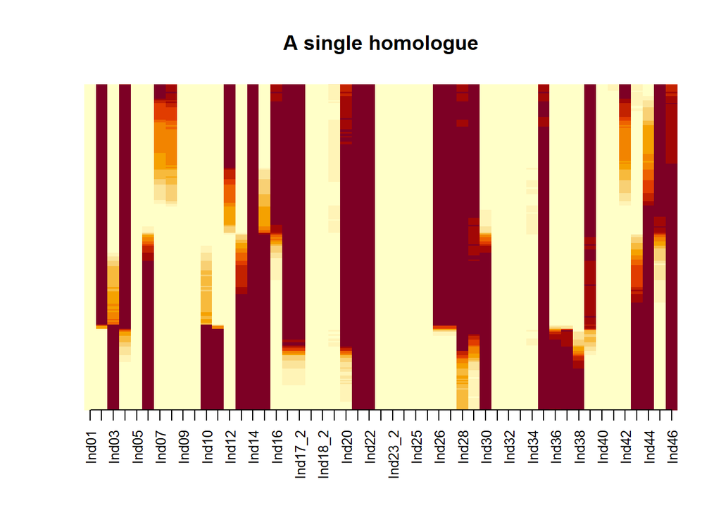

```r
#Many individuals, a single homologue: a matrix
ibd <- predict_IBD(IBD$H1_P1,map = map)
graphical_genotype(ibd, main = "A single homologue")
```

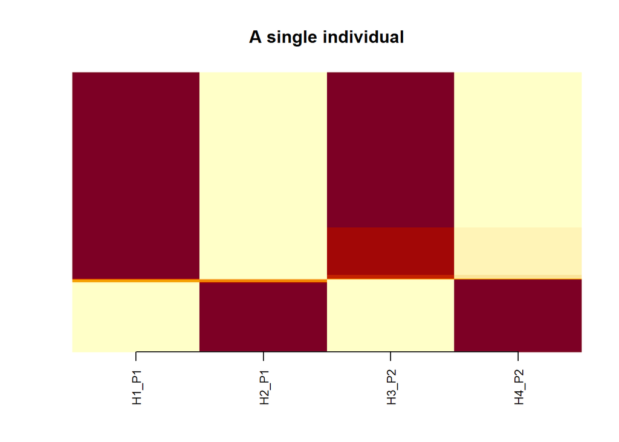

```r
#All homologues of one individual
ibd <- predict_IBD(extract(IBD,"Ind02"),map = map)
graphical_genotype(ibd, main = "A single individual")
```

```r
#All homologues of all individuals: a list of IBD matrices
ibd <- predict_IBD(IBD,map = map)
graphical_genotype(ibd)
```

[output not shown]

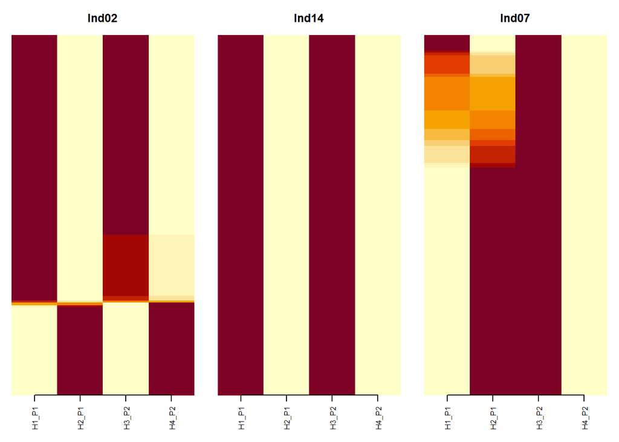

```r
#Multiple individuals
ibd <- predict_IBD(extract(IBD,c("Ind02","Ind14","Ind07")),map = map)
graphical_genotype(ibd)
```

### Genotype

The `genotype()` function takes in an IBD matrix (usually newIBD) and computes the set of genotypes corresponding to those IBDs. You can add a threshold, all predictions with a probability below the threshold will be given an NA as a result. If a matrix is given, it is assumed that it contains all homologue probabilities for a single individual!

```r
#We calculate IBDs removing the genotypes of the parents
IBD <- calc_IBD(geno[,-1:-2],p1hom = hom[,1:2],p2hom = hom[,3:4])
#In this case there's no change to the IBD matrix so there's no change in genotypes
newgeno <- genotype(IBD,homologue = hom)
all(newgeno == geno[,-1:-2])
```

```
## [1] TRUE
```

```r
#For one individual
ibd <- extract(IBD,"Ind02")
gen <- genotype(ibd,hom)
#Again all genotypes are the same as the originals
all(gen == geno[,"Ind02"])
```

```
## [1] TRUE
```

[^1]: Os, Hans & Stam, Piet & Visser, Richard & Eck, Herman. (2006). SMOOTH: A statistical method for successful removal of genotyping errors from high-density genetic linkage data. TAG. Theoretical and applied genetics. Theoretische und angewandte Genetik. DOI: 10.1007/s00122-005-0124-y. https://link.springer.com/article/10.1007/s00122-005-0124-y